# Image Classification with MNIST Dataset

**Deep Learning with TensorFlow 2.0 in Python**

by [Nosheen Altaf](https://www.linkedin.com/in/nosheen-altaf-565158a/)

## Deep Learning:

Artificial neural networks (ANNs) are a family of models inspired by biological neural networks and are used to estimate a functions that can depend on a large number of inputs and are generally unknown. **Deep Learning**, is just a NN with many hidden layers causing it to be deep.

## TensorFlow Introduction and Background:

TensorFlow is an open source software library developed by Google, it's a leading library for NN. In 2017, Keras was integrated into the core TensorFlow and is conceived as an interface for TensorFlow rather than a different library. In 2019, TesnsorFlow 2.0 came on the horizon and it's not wrong to say that TensorFlow 2.0 is basically Keras with added new features.

## The MNIST DATA:

The MNIST is a database of 70,000 handwritten digits, with a training set of 60,000 examples, and a test set of 10,000 examples. The data is clean and preprocessed. Each image in the data set is 28 x 28 pixels(i-e 784 pixels) , represented by 28x28 matrix where input values ranging from 0 to 255 with 0 indicating pure black and 255 indicating pure white. (i-e 256 shades of grey)

## NN Fundamentals

**Objective Function:**  
Our objective is to minimize the loss i-e minimize the error. we can use Cross-Entropy for Classification Problems.

**Optimization Algorithm:**

The most fundamental Algorithm is Gradient Descent(GD) and Stochastic Gradient Descent (SGD).In Gradient descent, we find the minimum value of the function by trial and error , each trial is better than the previous one (trial / iteration).

*Learning rate* should be high enough so we can reach the closet minimum in a rational amount of time, and should be low enough that we don't oscillate forever around the minimum. To avoid local minimum , we can add *momentum* to the algorithm.

*ADAM(Adaptive moment estimation)* is most advanced optimizer applied in practice, it includes momentum and learning rates both.

**Activation Function:**

Activation functions transform inputs into outputs of different kinds. Also called transfer functions. Most frequently activation functions are sigmoid,TanH, Relu and softmax

**Parameters and Hyper-Parameters of NN:**

*Parameters* are weights and biases

*Hyper-Parameters* are Width(input layer size), Depth(no. of hidden layers), Learning rate, Batch size etc

## Key words :

```
NN, GD, SGD, relu, softmax, keras, layers, flatten, dense, batch, weights,momentum, learning rate, bias, epochs, verbose, loss, accuracy, adam, one-hot-encoding
```

Please note, this notebook is prepared with the latest version of TesnorFlow, we can check our Version using following command

```python
import tensorflow as tf
print(tf.__version__)
```

```
2.0.0
```

## Get the Data

```python
import tensorflow_datasets as tfds
```

```python
mnist_dataset,mnist_info=tfds.load(name='mnist',with_info=True, as_supervised=True)
```

*as_supervised* will load the data in a tuple of input and label

*with_info* will load meta data info

```python
mnist_info #lets review  meta data info
```

```
tfds.core.DatasetInfo(
    name='mnist',
    version=1.0.0,
    description='The MNIST database of handwritten digits.',
    urls=['https://storage.googleapis.com/cvdf-datasets/mnist/'],
    features=FeaturesDict({
        'image': Image(shape=(28, 28, 1), dtype=tf.uint8),
        'label': ClassLabel(shape=(), dtype=tf.int64, num_classes=10),
    }),
    total_num_examples=70000,
    splits={
        'test': 10000,
        'train': 60000,
    },
    supervised_keys=('image', 'label'),
    citation="""@article{lecun2010mnist,
      title={MNIST handwritten digit database},
      author={LeCun, Yann and Cortes, Corinna and Burges, CJ},
      journal={ATT Labs [Online]. Available: http://yann. lecun. com/exdb/mnist},
      volume={2},
      year={2010}
    }""",
    redistribution_info=,
)
```

```python
type(mnist_dataset) #type of mnist_dataset
```

```
dict
```

```python
mnist_dataset # test and train are the keys
```

```
{'test': <_OptionsDataset shapes: ((28, 28, 1), ()), types: (tf.uint8, tf.int64)>,
 'train': <_OptionsDataset shapes: ((28, 28, 1), ()), types: (tf.uint8, tf.int64)>}
```

So the mnist data is iterable and in 2-tuple format

## Train, Test Split

As we know , data is already being splitted into train and test. All we need to do tuple unpacking

```python
mnist_train, mnist_test=mnist_dataset['train'],mnist_dataset['test']
```

```python
mnist_info.splits['train'].num_examples # to see number of train examples
```

```
60000
```

```python
mnist_info.splits['test'].num_examples # to see number of test examples
```

```
10000
```

## Data Preprocessing

Lets explore the data by selecting one sample randomly

```python
train_input,train_label=next(iter(mnist_train.shuffle(1000)))
```

lets plot this to better understand the structure of our data

```python
import numpy as np
import matplotlib.pyplot as plt
%matplotlib inline
```

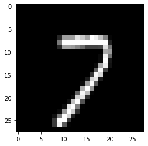

```python
plt.imshow(np.reshape(train_input, [28, 28]), cmap='gray')
plt.show()
```

Now we can actually visualize that each sample is consist of an image of 28x28 matrix i-e 784 values within a matrix ranging from 0 to 255.

before modeling this data, we will do some preprocessing by

**1. Scaling the Data**

We will scale the data between 0 and 1 , this can be achieved by dividing each element in matrix by 255

**2. Shuffling the Data**

Our data is very big, we will shuffle in batches i-e take *n* sample and shuffle and then take next *n* sample and shuffle .

**3. Creating Batches of Training Data**

Lets decide a batch size of 100, that means, each epoch will have 600 batches of size 100 to process 60,000 sample in an epoch.

```python
def scale(image,label):
    image=tf.cast(image,tf.float32)
    image/=255.
    return image,label
```

```python
scaled_train=mnist_train.map(scale)
```

```python
scaled_test=mnist_test.map(scale)
```

```python
shuffled_train=scaled_train.shuffle(10000) #buffer size is 10,000
```

```python
train_data=shuffled_train.batch(100) #batch size is 100
```

We don't need to batch our test data, we should take all the data at once for model evaluation.

```python
test_data=scaled_test.batch(10000)# i-e num of test samples
```

# Outline the Model

**1. Input layer**

Since each sample has 784 data values, the size of input layer will be 784

**2. Output layer**

We want to classify each image into 10 possible categories so the output layer size will be 10.

**3. Hidden layers**

We can play around with number and size of hidden layers to tune our model, in our case, two hidden layers with size 100 are enough to produce a model with very good accuracy

```python
input_size=784
output_size=10
hidden_layer_size=100

model=tf.keras.Sequential([
                          tf.keras.layers.Flatten(input_shape=(28,28,1)),
                          tf.keras.layers.Dense(hidden_layer_size,activation='relu'), #first hidden layer
                          tf.keras.layers.Dense(hidden_layer_size,activation='relu'), #second hidden layer
                          tf.keras.layers.Dense(output_size,activation='softmax'), #output layer
                         ])
```

*tf.keras.layers.Flatten()* transform or flattens a tensor into a vector ,here we will get a vector of (784x1).

When we create a classifier, the activation function of the output layer must transform the values into probabilities. Therefore, *softmax* is a good choice.

Lets compile our model by deciding optimizer and loss function

```python
model.compile(optimizer='adam',loss='sparse_categorical_crossentropy',metrics=['accuracy'])
```

# Model Training

Lets decide number of iteration/epochs, we wish to train for. Please note that including too many epochs can cause over fitting. We can set the maximum number of epochs with the condition to terminate training based on the validation and training error rates. We can use *callback* and *Early Stopping* option for this with the inclusion of validation data

```python
num_epochs=10 #i-e number of iterations
```

```python
model.fit(train_data,epochs=num_epochs,verbose=2)
#verbose to show the progress after every epochs/iteration
#verbose=2 will result one line per epoch(easy to follow the development of the loss)
```

```
600/600 - 9s - loss: 0.3171 - accuracy: 0.9097
600/600 - 12s - loss: 0.1322 - accuracy: 0.9617
600/600 - 12s - loss: 0.0925 - accuracy: 0.9711
600/600 - 12s - loss: 0.0695 - accuracy: 0.9789
600/600 - 12s - loss: 0.0556 - accuracy: 0.9835
600/600 - 13s - loss: 0.0448 - accuracy: 0.9862
600/600 - 12s - loss: 0.0376 - accuracy: 0.9883
600/600 - 12s - loss: 0.0310 - accuracy: 0.9902
600/600 - 13s - loss: 0.0252 - accuracy: 0.9922
600/600 - 13s - loss: 0.0226 - accuracy: 0.9930
```

```
<tensorflow.python.keras.callbacks.History at 0x20d37341a88>
```

We can play around with hidden layers size from 100 to 200, 300 etc, and number of hidden layers from 2 to 3,4 etc

# Model2

Lets create another model with 3 hidden layers of size 200

```python
input_size2=784
output_size2=10
hidden_layer_size2=200

model2=tf.keras.Sequential([
                          tf.keras.layers.Flatten(input_shape=(28,28,1)),
                          tf.keras.layers.Dense(hidden_layer_size2,activation='relu'), #first hidden layer
                          tf.keras.layers.Dense(hidden_layer_size2,activation='relu'), #second hidden layer
                          tf.keras.layers.Dense(hidden_layer_size2,activation='relu'), #third hidden layer
                          tf.keras.layers.Dense(output_size2,activation='softmax'), #output layer
                         ])
```

```python
model2.compile(optimizer='adam',loss='sparse_categorical_crossentropy',metrics=['accuracy'])
```

```python
model2.fit(train_data,epochs=num_epochs,verbose=2)
#verbose to show the progress after every epochs/iteration
#verbose=2 will result one line per epoch(easy to follow the development of the loss)
```

```
600/600 - 11s - loss: 0.2542 - accuracy: 0.9248
600/600 - 13s - loss: 0.0963 - accuracy: 0.9705
600/600 - 14s - loss: 0.0652 - accuracy: 0.9794
600/600 - 13s - loss: 0.0488 - accuracy: 0.9843
600/600 - 13s - loss: 0.0369 - accuracy: 0.9877
600/600 - 14s - loss: 0.0336 - accuracy: 0.9886
600/600 - 13s - loss: 0.0259 - accuracy: 0.9912
600/600 - 14s - loss: 0.0225 - accuracy: 0.9929
600/600 - 13s - loss: 0.0215 - accuracy: 0.9928
600/600 - 14s - loss: 0.0166 - accuracy: 0.9945
```

```
<tensorflow.python.keras.callbacks.History at 0x20d38678788>
```

# Testing the Models

```python
test_loss,test_accuracy=model.evaluate(test_data)
```

```python
test_loss2,test_accuracy2=model2.evaluate(test_data)
```

```python
print('Test loss of Model 1:{0: .2f}. Test Accuracy of Model 1: {1:2f}%'.format(test_loss, test_accuracy*100.))
print('Test loss of Model 2:{0: .2f}. Test Accuracy of Model 2: {1:2f}%'.format(test_loss2, test_accuracy2*100.))
```

```
Test loss of Model 1: 0.10. Test Accuracy of Model 1: 97.030002%
Test loss of Model 2: 0.09. Test Accuracy of Model 2: 97.770000%
```

# Conclusion

There are many rule-of-thumb methods for determining the correct number of neurons to use in the hidden layers, such as the following:

1: The number of hidden neurons should be between the size of the input layer and the size of the output layer.

2: The number of hidden neurons should be 2/3 the size of the input layer, plus the size of the output layer.

3: The number of hidden neurons should be less than twice the size of the input layer.

check references for more details

# References

1: http://yann.lecun.com/exdb/mnist/

2: https://www.tensorflow.org/

3: https://www.udemy.com/course/machine-learning-with-tensorflow-for-business-intelligence/

4: https://www.researchgate.net/post/How_to_decide_the_number_of_hidden_layers_and_nodes_in_a_hidden_layer